# Advanced Research Dataset Homeworks

### 1.c. Report the results of the analysis.

In the selected model (`mr.fit5`), highest year of school completed (`educ`), illegal drugs (`hlth5`) and (`race`) significantly accounted for approximately 28% of the variance of occupational prestige (`prestg80`). The model was significant, ($F$(4,940) = 93.61, $p$ < .001).

### 1.d. Repeat this analysis separately for men and women. Are there any major differences in

the pattern of results for these two groups?

We separate the data using pipes `%>%` and the `tidyverse` package (`dyplr`)

```r
men.data <- EX9Q1 %>% filter(sex == 1)
men.fit <- lm(prestg80 ~ happy + childs + educ + hlth5 + hlth4 +
                as.factor(race), data = men.data)
summary(men.fit)
```

```
##
## Call:
## lm(formula = prestg80 ~ happy + childs + educ + hlth5 + hlth4 +
##     as.factor(race), data = men.data)
##
## Residuals:
## <Labelled double>: R's Occupational Prestige Score (1980)
##      Min       1Q   Median       3Q      Max
## -28.6196  -7.7728  -0.3973   7.5305  28.9437
##
## Labels:
##  value     label
##      0 DK,NA,NAP
##
## Coefficients:
##                  Estimate Std. Error t value Pr(>|t|)
## (Intercept)       5.60958    9.55430   0.587    0.557
## happy            -0.95896    0.96465  -0.994    0.321
## childs            0.06713    0.34588   0.194    0.846
## educ              1.86065    0.18267  10.186  < 2e-16 ***
## hlth5            10.50286    2.52832   4.154 4.01e-05 ***
## hlth4            -2.04827    4.13409  -0.495    0.621
## as.factor(race)2 -7.32852    1.84228  -3.978 8.28e-05 ***
## as.factor(race)3 -2.19857    3.20170  -0.687    0.493
## ---
## Signif. codes:  0 '***' 0.001 '**' 0.01 '*' 0.05 '.' 0.1 ' ' 1
##
## Residual standard error: 11.3 on 393 degrees of freedom
##   (235 observations deleted due to missingness)
## Multiple R-squared:  0.3041, Adjusted R-squared:  0.2917
## F-statistic: 24.54 on 7 and 393 DF,  p-value: < 2.2e-16
```

It seems that for men, education, drug use and race are highly predictive of occupational prestige score; they account for approximately 29% of the variance of job prestige, and the model was significant ($F$(7,393) = 24.54, $p$ < .001).

```r
women.data <- EX9Q1 %>% filter(sex == 2)
women.fit <- lm(prestg80 ~ happy + childs + educ + hlth5 + hlth4 + as.factor(race), data = women.data)
summary(women.fit)
```

```
##
## Call:
## lm(formula = prestg80 ~ happy + childs + educ + hlth5 + hlth4 +
##     as.factor(race), data = women.data)
##
## Residuals:
## <Labelled double>: R's Occupational Prestige Score (1980)
##     Min      1Q  Median      3Q     Max
## -31.632  -8.307   0.116   6.945  28.028
##
## Labels:
##  value     label
##      0 DK,NA,NAP
##
## Coefficients:
##                  Estimate Std. Error t value Pr(>|t|)
## (Intercept)        6.1826    11.8270   0.523   0.6014
## happy             -0.6977     0.7589  -0.919   0.3583
## childs             0.2777     0.2924   0.950   0.3426
## educ               2.5894     0.1851  13.987   <2e-16 ***
## hlth5             -5.0361     4.5126  -1.116   0.2649
## hlth4              7.2431     3.8945   1.860   0.0635 .
## as.factor(race)2  -1.9813     1.3789  -1.437   0.1514
## as.factor(race)3  -1.5673     2.9415  -0.533   0.5944
## ---
## Signif. codes:  0 '***' 0.001 '**' 0.01 '*' 0.05 '.' 0.1 ' ' 1
##
## Residual standard error: 10.79 on 524 degrees of freedom
##   (349 observations deleted due to missingness)
## Multiple R-squared:  0.2995, Adjusted R-squared:  0.2902
## F-statistic: 32.01 on 7 and 524 DF,  p-value: < 2.2e-16
```

# Dataset 2 - Analyses of Variance

### 1. Load the data file Ex8Q1.sav. This file contains the data collected during a study of the effects of time on memory for details of a crime. A total of thirty five participants watched a video of a crime. They were then interviewed either one, two or three days later. Participants’ memory for the details of the crime was scored out of a total of 50.

### 1.a. First, to check whether the allocation of participants to conditions was random, compare the age of the participants in the three groups. Is the result good news for the experimenters?

Compare age of participants in groups:

```r
na.omit(Ex8Q1) %>%
  group_by(Delay)%>%
  dplyr::select(Age)%>%
  summarize_all(mean)
```

| Delay | Age |
| --- | --- |
| 1 | 20.58333 |
| 2 | 20.25000 |
| 3 | 20.00000 |

```r
#good news for experiments. Mean age is about the same for all three grps
```

```r
#confirm using base R
mean(na.omit(Ex8Q1[Ex8Q1$Delay == 1,]$Age))
```

```
## [1] 20.58333
```

```r
mean(na.omit(Ex8Q1[Ex8Q1$Delay == 2,]$Age))
```

```
## [1] 20.25
```

```r
mean(na.omit(Ex8Q1[Ex8Q1$Delay == 3,]$Age))
```

```
## [1] 20
```

### 1.b. Now test the hypothesis that the duration of the delay between encoding and recall will affect the accuracy of recall. Report the result of your analysis.

Fit ANOVA model

```r
aov.fit <- aov(Recall~as.factor(Delay), data = Ex8Q1)

#summary
summary(aov.fit)
```

```
##                  Df Sum Sq Mean Sq F value   Pr(>F)
## as.factor(Delay)  2  625.0  312.52    21.5 1.21e-06 ***
## Residuals        32  465.2   14.54
## ---
## Signif. codes:  0 '***' 0.001 '**' 0.01 '*' 0.05 '.' 0.1 ' ' 1
## 1 observation deleted due to missingness
```

The duration of delay between encoding and recall will affect the accuracy of recall ($F$(2,32) = 21.5, $p$ < .001).

### 1.c. Produce a graph showing recall at each delay, and perform post-hoc tests to determine whether each increase in delay results in a significant decrease in recall.

Graph

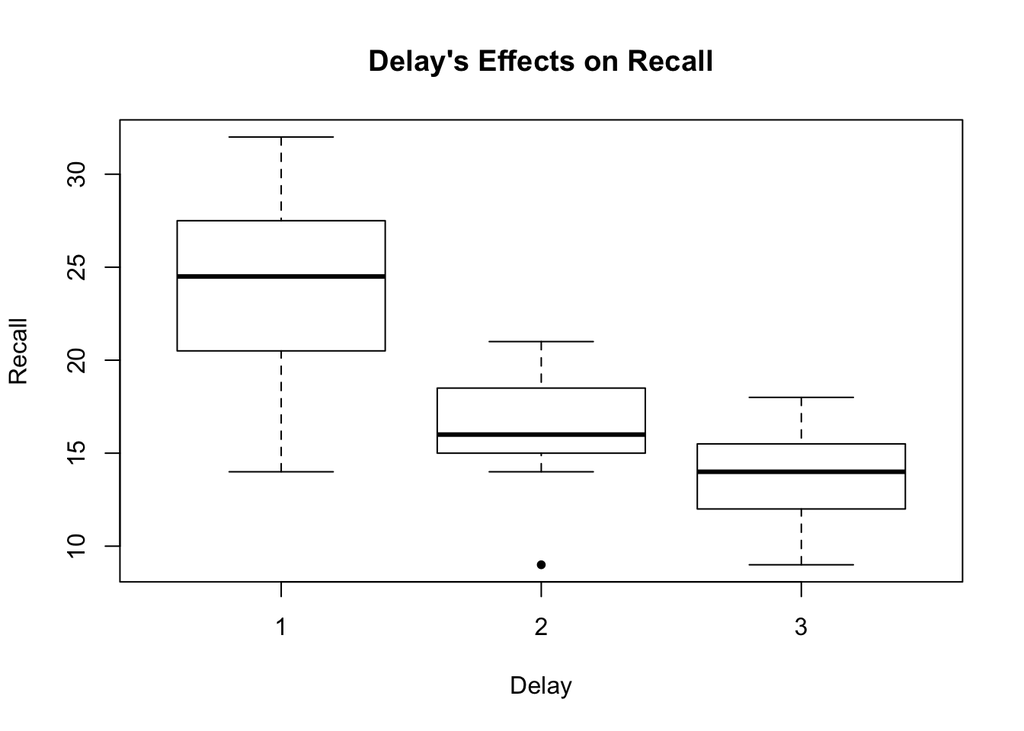

Graph depicting the effects of delay on recall

```r
boxplot(Recall~Delay, data = Ex8Q1, pch = 20, main = "Delay's Effects on Recall")
```

Now we confirm with a post-hoc test:

```r
#Tukey Honest Significant Differences test
TukeyHSD(aov.fit)
```

```
##   Tukey multiple comparisons of means
##     95% family-wise confidence level
##
## Fit: aov(formula = Recall ~ as.factor(Delay), data = Ex8Q1)
##
## $`as.factor(Delay)`
##          diff        lwr       upr     p adj
## 2-1 -7.500000 -11.325250 -3.674750 0.0000978
## 3-1 -9.924242 -13.835464 -6.013021 0.0000016
## 3-2 -2.424242  -6.335464  1.486979 0.2937774
```

```r
cohen.d(Ex8Q1[,4:5],"Delay")
```

```
## Call: cohen.d(x = Ex8Q1[, 4:5], group = "Delay")
## Cohen d statistic of difference between two means
##        lower effect upper
## Recall  -2.9   -1.8 -0.72
##
## Multivariate (Mahalanobis) distance between groups
## [1] 1.8
## r equivalent of difference between two means
## Recall
##  -0.68
```

Differences in 1-2 and 1-3 are significant, but 2-3 is not. Overall, delay has a major detrimental effect on recall (Cohen’s $d$ = -1.8).

### 2. A psychologist is evaluating a prison-based treatment program for violent offenders serving long sentences. The psychologist was given access to the prison records which included information about any official reprimands received, or misdemeanours committed by the offenders. She used this information to calculate a behaviour score for each offender (high value indicates poor behaviour). The psychologist calculated this score for the year immediately prior to treatment, for the year of treatment and for each of the first and second years following treatment. The file Ex8Q2.sav contains the data from 12 prisoners.

### 2.a. Does the behaviour score change significantly across the four years?

Probably the easiest way to see the change is with a boxplot (HOW we should find out was not specified).

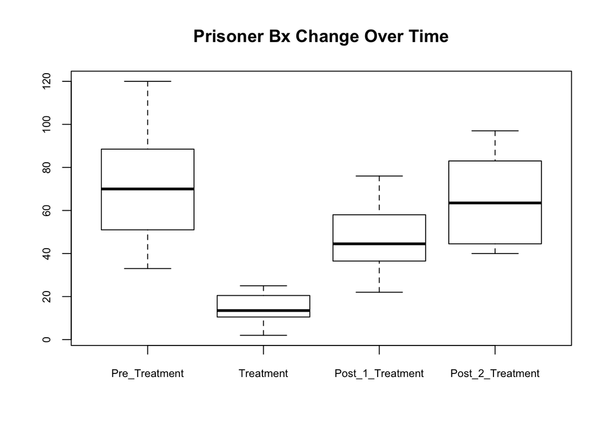

```r
boxplot(Ex8Q2[,-1], cex.axis = 0.75, main = "Prisoner Bx Change Over Time")
```

```r
#1st column is ID so we take it out with subsetting [,-1].
```

In order to use the ezANOVA function in “ez” package, we need “long” data this means that each kind of treatment for each prisoner needs to have its own column. We use the `reshape` package to `melt` the data.

```r
ldata <- melt(data.frame(Ex8Q2),
                 id = "Prisoner_ID",
                 tx = c("Pre_Treatment","Treatment","Post_1_Treatment","Post_2_Treatment"))
colnames(ldata) <- c("id","tx","score") #name the columns to variable names (iv/dv)
head(ldata) #the head() function prints the 1st six rows of the data.frame
```

|  | id | tx | score |
| --- | --- | --- | --- |
| 1 | 1 | Pre_Treatment | 46 |
| 2 | 2 | Pre_Treatment | 66 |
| 3 | 3 | Pre_Treatment | 44 |
| 4 | 4 | Pre_Treatment | 89 |
| 5 | 5 | Pre_Treatment | 88 |
| 6 | 6 | Pre_Treatment | 62 |

Run the ANOVA:

```r
ezANOVA(
  data = ldata,
  wid = id, #this asks for the participant's ID
  within = tx, #the "within-subjects" condition
  dv = score, #the dependent variable
  type =3 #this asks for a certain type of math - type 3 SPSS-comparable results
)
```

```
## $ANOVA
##   Effect DFn DFd        F            p p<.05       ges
## 2     tx   3  33 34.85599 2.427302e-10     * 0.6208088
##
## $`Mauchly's Test for Sphericity`
##   Effect         W         p p<.05
## 2     tx 0.4511836 0.1732339
##
## $`Sphericity Corrections`
##   Effect       GGe        p[GG] p[GG]<.05       HFe        p[HF] p[HF]<.05
## 2     tx 0.6534505 1.955834e-07         * 0.7936968 1.294157e-08         *
```

```r
#Mauchly's test of sphericity is not significant, assumptions are met without need
#of corrections.
```

### 2.b. During treatment the prisoners are housed in a special unit, and as a result the behaviour score for the year of treatment may not be comparable to the measures taken before and after treatment. Reanalyse the data excluding this data point.

Now we’re going to run it again minus the “Treatment” condition (2 ways to do this):

```r
ezANOVA(
  data = ldata[which(ldata$tx!="Treatment"),], #subsetting out the condition
  wid = id,
  within = tx,
  dv = score,
  type =3
)
```

```
## $ANOVA
##   Effect DFn DFd        F           p p<.05       ges
## 2     tx   2  22 8.064098 0.002360156     * 0.2253756
##
## $`Mauchly's Test for Sphericity`
##   Effect         W         p p<.05
## 2     tx 0.7659468 0.2636289
##
## $`Sphericity Corrections`
##   Effect       GGe       p[GG] p[GG]<.05       HFe       p[HF] p[HF]<.05
## 2     tx 0.8103378 0.004856575         * 0.9301367 0.003076188         *
```

```r
#or re-fitting the data in the 'melting' process...
ldata2 <- melt(data.frame(Ex8Q2[,-3]),
               id = "Prisoner_ID",
               tx = c("Pre_Treatment","Post_1_Treatment","Post_2_Treatment"))
colnames(ldata2) <- c("id","tx","score") #name the columns to variable names (iv/dv)

ezANOVA(
  data = ldata2,
  wid = id,
  within = tx,
  dv = score,
  type =3
)
```

```
## $ANOVA
##   Effect DFn DFd        F           p p<.05       ges
## 2     tx   2  22 8.064098 0.002360156     * 0.2253756
##
## $`Mauchly's Test for Sphericity`
##   Effect         W         p p<.05
## 2     tx 0.7659468 0.2636289
##
## $`Sphericity Corrections`
##   Effect       GGe       p[GG] p[GG]<.05       HFe       p[HF] p[HF]<.05
## 2     tx 0.8103378 0.004856575         * 0.9301367 0.003076188         *
```

The result is still significant.

### 2.c. The psychologist planned to compare the behaviour at one year and two years post treatment with the behaviour prior to treatment. Undertake a contrast which includes these comparisons.

Given that I’m using another package to calculate the repeated measures ANOVA, I’m not able to conduct post-hoc tests because I’m not getting so much an “object” as a “list” with the results. Instead, I complete comparisons using paired samples t-tests, using my “wide” data (original or raw data)

```r
t.test(Ex8Q2$Pre_Treatment,Ex8Q2$Post_1_Treatment, paired = TRUE) #significant
```

```
##
##  Paired t-test
##
## data:  Ex8Q2$Pre_Treatment and Ex8Q2$Post_1_Treatment
## t = 3.1311, df = 11, p-value = 0.009559
## alternative hypothesis: true difference in means is not equal to 0
## 95 percent confidence interval:
##   7.302683 41.863984
## sample estimates:
## mean of the differences
##                24.58333
```

```r
t.test(Ex8Q2$Pre_Treatment,Ex8Q2$Post_2_Treatment, paired = TRUE) #not significant
```

```
##
##  Paired t-test
##
## data:  Ex8Q2$Pre_Treatment and Ex8Q2$Post_2_Treatment
## t = 0.91939, df = 11, p-value = 0.3776
## alternative hypothesis: true difference in means is not equal to 0
## 95 percent confidence interval:
##  -7.318368 17.818368
## sample estimates:
## mean of the differences
##                    5.25
```

The other option is using `pairwise.t.test()`, which takes the values of a vector (x) by groups (g)… for which I can use the “long data” that I created for the repeated measures ANOVA. This is important because if I were doing a lot of these I wouldn’t want to keep switching between the two. It helps for preventing errors and increasing reproducibility. It also lets me use p-value adjustments (e.g., “Bonferroni” correction).

```r
pairwise.t.test(ldata2$score, ldata2$tx, p.adjust.method = "bonf", paired = TRUE)
```

```
##
##  Pairwise comparisons using paired t tests
##
## data:  ldata2$score and ldata2$tx
##
##                  Pre_Treatment Post_1_Treatment
## Post_1_Treatment 0.029         -
## Post_2_Treatment 1.000         0.015
##
## P value adjustment method: bonferroni
```

```r
#Using Bonferroni correction
```